# ISLR: Chapter 3 Problems

## Problem 8 (a)

```r
library(ISLR)
attach(Auto)
lm.fit<-lm(mpg~horsepower)
summary(lm.fit)
```

```
Call:
lm(formula = mpg ~ horsepower)

Residuals:
     Min       1Q   Median       3Q      Max
-13.5710  -3.2592  -0.3435   2.7630  16.9240

Coefficients:
             Estimate Std. Error t value Pr(>|t|)
(Intercept) 39.935861   0.717499   55.66   <2e-16 ***
horsepower  -0.157845   0.006446  -24.49   <2e-16 ***
---
Signif. codes:  0 ‘***’ 0.001 ‘**’ 0.01 ‘*’ 0.05 ‘.’ 0.1 ‘ ’ 1

Residual standard error: 4.906 on 390 degrees of freedom
Multiple R-squared:  0.6059,    Adjusted R-squared:  0.6049
F-statistic: 599.7 on 1 and 390 DF,  p-value: < 2.2e-16
```

1. Yes
2. mpg is -0.158 times horsepower
3. negative

### Prediction and intervals

```r
predict(lm.fit,data.frame(horsepower=(c(98))),interval="confidence")
```

```
       fit      lwr      upr
1 24.46708 23.97308 24.96108
```

```r
predict(lm.fit,data.frame(horsepower=(c(98))),interval="prediction")
```

```
       fit     lwr      upr
1 24.46708 14.8094 34.12476
```

2. Plots

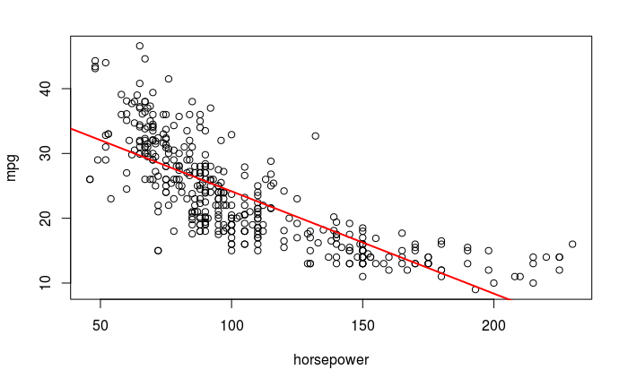

```r
plot(horsepower,mpg)
abline(lm.fit,lwd=2,col="red")
```

Diagnostic plots

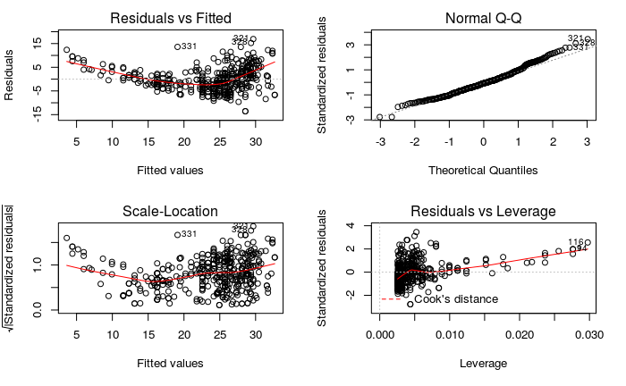

```r
par(mfrow=c(2,2))
plot(lm.fit)
```

Residuals are non linear. Few high leverage and high studentized residual(>3) points

## Problem 9

1. All plots

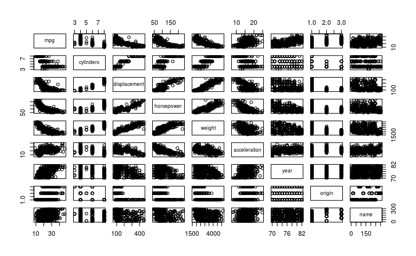

```r
pairs(Auto)
```

## Correlation

```r
cor(Auto[-9])
```

```
                    mpg  cylinders displacement horsepower     weight acceleration
mpg           1.0000000 -0.7776175   -0.8051269 -0.7784268 -0.8322442    0.4233285
cylinders    -0.7776175  1.0000000    0.9508233  0.8429834  0.8975273   -0.5046834
displacement -0.8051269  0.9508233    1.0000000  0.8972570  0.9329944   -0.5438005
horsepower   -0.7784268  0.8429834    0.8972570  1.0000000  0.8645377   -0.6891955
weight       -0.8322442  0.8975273    0.9329944  0.8645377  1.0000000   -0.4168392
acceleration  0.4233285 -0.5046834   -0.5438005 -0.6891955 -0.4168392    1.0000000
year          0.5805410 -0.3456474   -0.3698552 -0.4163615 -0.3091199    0.2903161
origin        0.5652088 -0.5689316   -0.6145351 -0.4551715 -0.5850054    0.2127458
                   year     origin
mpg           0.5805410  0.5652088
cylinders    -0.3456474 -0.5689316
displacement -0.3698552 -0.6145351
horsepower   -0.4163615 -0.4551715
weight       -0.3091199 -0.5850054
acceleration  0.2903161  0.2127458
year          1.0000000  0.1815277
origin        0.1815277  1.0000000
```

## Fiting a linear model

```r
lm.fit<-lm(mpg~.-name,data=Auto)
summary(lm.fit)
```

```
Call:
lm(formula = mpg ~ . - name, data = Auto)

Residuals:
    Min      1Q  Median      3Q     Max
-9.5903 -2.1565 -0.1169  1.8690 13.0604

Coefficients:
               Estimate Std. Error t value Pr(>|t|)
(Intercept)  -17.218435   4.644294  -3.707  0.00024 ***
cylinders     -0.493376   0.323282  -1.526  0.12780
displacement   0.019896   0.007515   2.647  0.00844 **
horsepower    -0.016951   0.013787  -1.230  0.21963
weight        -0.006474   0.000652  -9.929  < 2e-16 ***
acceleration   0.080576   0.098845   0.815  0.41548
year           0.750773   0.050973  14.729  < 2e-16 ***
origin         1.426141   0.278136   5.127 4.67e-07 ***
---
Signif. codes:  0 ‘***’ 0.001 ‘**’ 0.01 ‘*’ 0.05 ‘.’ 0.1 ‘ ’ 1

Residual standard error: 3.328 on 384 degrees of freedom
Multiple R-squared:  0.8215,    Adjusted R-squared:  0.8182
F-statistic: 252.4 on 7 and 384 DF,  p-value: < 2.2e-16
```

- Displacement, weight, year and origin has a relation to the mpg
- Year, don’t know

Residual plots

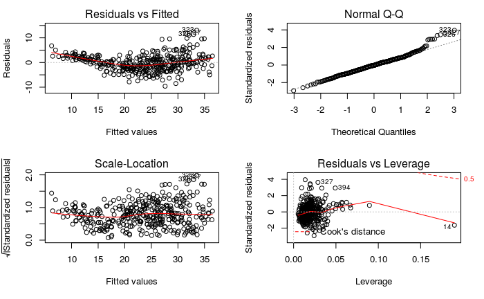

```r
par(mfrow=c(2,2))
plot(lm.fit)
```

The residuals are non linear. The leverage for point 14 is high.

Linear model with interaction term

```r
lm2.fit<-lm(mpg~.-name+displacement:weight+displacement:year,data=Auto)
summary(lm2.fit)
```

```
Call:
lm(formula = mpg ~ . - name + displacement:weight + displacement:year,
    data = Auto)

Residuals:
    Min      1Q  Median      3Q     Max
-8.6499 -1.5864 -0.0841  1.3300 13.2550

Coefficients:
                      Estimate Std. Error t value Pr(>|t|)
(Intercept)         -4.038e+01  7.511e+00  -5.376 1.33e-07 ***
cylinders            4.220e-01  2.885e-01   1.463 0.144382
displacement         1.287e-01  3.687e-02   3.492 0.000536 ***
horsepower          -4.215e-02  1.204e-02  -3.502 0.000517 ***
weight              -9.700e-03  7.075e-04 -13.709  < 2e-16 ***
acceleration         8.766e-02  8.485e-02   1.033 0.302210
year                 1.215e+00  8.861e-02  13.714  < 2e-16 ***
origin               5.159e-01  2.526e-01   2.042 0.041798 *
displacement:weight  2.004e-05  2.225e-06   9.010  < 2e-16 ***
displacement:year   -2.597e-03  4.651e-04  -5.584 4.48e-08 ***
---
Signif. codes:  0 ‘***’ 0.001 ‘**’ 0.01 ‘*’ 0.05 ‘.’ 0.1 ‘ ’ 1

Residual standard error: 2.854 on 382 degrees of freedom
Multiple R-squared:  0.8694,    Adjusted R-squared:  0.8663
F-statistic: 282.6 on 9 and 382 DF,  p-value: < 2.2e-16
```

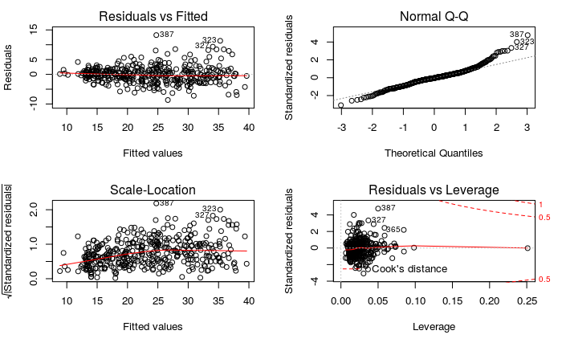

```r
par(mfrow=c(2,2))
plot(lm2.fit)
```

## Problem 10

```r
lm.fit1<-lm(Sales~Price+Urban+US,data=Carseats)
summary(lm.fit1)
```

```
Call:
lm(formula = Sales ~ Price + Urban + US, data = Carseats)

Residuals:
    Min      1Q  Median      3Q     Max
-6.9206 -1.6220 -0.0564  1.5786  7.0581

Coefficients:
             Estimate Std. Error t value Pr(>|t|)
(Intercept) 13.043469   0.651012  20.036  < 2e-16 ***
Price       -0.054459   0.005242 -10.389  < 2e-16 ***
UrbanYes    -0.021916   0.271650  -0.081    0.936
USYes        1.200573   0.259042   4.635 4.86e-06 ***
---
Signif. codes:  0 ‘***’ 0.001 ‘**’ 0.01 ‘*’ 0.05 ‘.’ 0.1 ‘ ’ 1

Residual standard error: 2.472 on 396 degrees of freedom
Multiple R-squared:  0.2393,    Adjusted R-squared:  0.2335
F-statistic: 41.52 on 3 and 396 DF,  p-value: < 2.2e-16
```

```r
lm.fit2<-lm(Sales~Price+US,data=Carseats)
summary(lm.fit2)
```

```
Call:
lm(formula = Sales ~ Price + US, data = Carseats)

Residuals:
    Min      1Q  Median      3Q     Max
-6.9269 -1.6286 -0.0574  1.5766  7.0515

Coefficients:
            Estimate Std. Error t value Pr(>|t|)
(Intercept) 13.03079    0.63098  20.652  < 2e-16 ***
Price       -0.05448    0.00523 -10.416  < 2e-16 ***
USYes        1.19964    0.25846   4.641 4.71e-06 ***
---
Signif. codes:  0 ‘***’ 0.001 ‘**’ 0.01 ‘*’ 0.05 ‘.’ 0.1 ‘ ’ 1

Residual standard error: 2.469 on 397 degrees of freedom
Multiple R-squared:  0.2393,    Adjusted R-squared:  0.2354
F-statistic: 62.43 on 2 and 397 DF,  p-value: < 2.2e-16
```

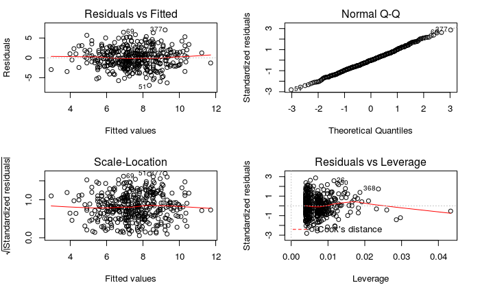

```r
par(mfrow=c(2,2))
plot(lm.fit2)
```

Studentized residual

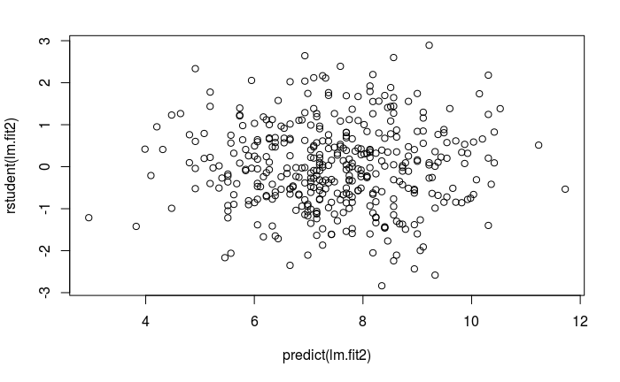

```r
plot(predict(lm.fit2), rstudent(lm.fit2))
```

## Confidence Interval

```r
confint(lm.fit2)
```

```
                  2.5 %      97.5 %
(Intercept) 11.79032020 14.27126531
Price       -0.06475984 -0.04419543
USYes        0.69151957  1.70776632
```

## Problem 11a

```r
set.seed(1)
x<-rnorm(100)
y<-2*x+rnorm(100)
lm.fit3<-lm(y~x+0)
summary(lm.fit3)
```

```
Call:
lm(formula = y ~ x + 0)

Residuals:
    Min      1Q  Median      3Q     Max
-1.9154 -0.6472 -0.1771  0.5056  2.3109

Coefficients:
  Estimate Std. Error t value Pr(>|t|)
x   1.9939     0.1065   18.73   <2e-16 ***
---
Signif. codes:  0 ‘***’ 0.001 ‘**’ 0.01 ‘*’ 0.05 ‘.’ 0.1 ‘ ’ 1

Residual standard error: 0.9586 on 99 degrees of freedom
Multiple R-squared:  0.7798,    Adjusted R-squared:  0.7776
F-statistic: 350.7 on 1 and 99 DF,  p-value: < 2.2e-16
```

## Problem 11b

```r
lm.fit4<-lm(x~y+0)
summary(lm.fit4)
```

```
Call:
lm(formula = x ~ y + 0)

Residuals:
    Min      1Q  Median      3Q     Max
-0.8699 -0.2368  0.1030  0.2858  0.8938

Coefficients:
  Estimate Std. Error t value Pr(>|t|)
y  0.39111    0.02089   18.73   <2e-16 ***
---
Signif. codes:  0 ‘***’ 0.001 ‘**’ 0.01 ‘*’ 0.05 ‘.’ 0.1 ‘ ’ 1

Residual standard error: 0.4246 on 99 degrees of freedom
Multiple R-squared:  0.7798,    Adjusted R-squared:  0.7776
F-statistic: 350.7 on 1 and 99 DF,  p-value: < 2.2e-16
```

Problem 13a-d

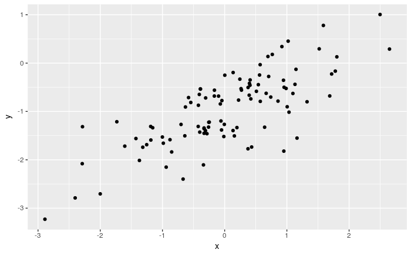

```r
x <- rnorm(100)
eps <- rnorm(100,sd=sqrt(.25))
y <- -1+0.5*x+eps
library(ggplot2)
# data frame to make ggplot easier
dt <- data.frame(y=y,x=x)
p <- ggplot(data=dt,aes(x=x,y=y))
p+geom_point()
```

Problem 13e

```r
lm.fit13e <- lm(y~x)
summary(lm.fit13e)
```

```
Call:
lm(formula = y ~ x)

Residuals:
     Min       1Q   Median       3Q      Max
-1.37090 -0.28070 -0.00874  0.33987  0.92421

Coefficients:
            Estimate Std. Error t value Pr(>|t|)
(Intercept) -0.97578    0.04955  -19.69   <2e-16 ***
x            0.55311    0.04813   11.49   <2e-16 ***
---
Signif. codes:  0 ‘***’ 0.001 ‘**’ 0.01 ‘*’ 0.05 ‘.’ 0.1 ‘ ’ 1

Residual standard error: 0.4953 on 98 degrees of freedom
Multiple R-squared:  0.574, Adjusted R-squared:  0.5697
F-statistic: 132.1 on 1 and 98 DF,  p-value: < 2.2e-16
```

Problem 13f : Creating plots

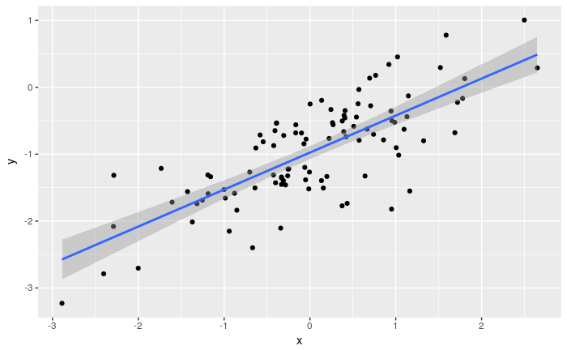

```r
p <- ggplot(data=dt,aes(x=x,y=y))
p+geom_point()+geom_smooth(method='lm',formula=y~x)
```

Problem 13g: Fitting a $x^2$ term to the linear regression

```r
lm.fit13g <- lm(y~x+I(x^2))
summary(lm.fit13g)
```

```
Call:
lm(formula = y ~ x + I(x^2))

Residuals:
     Min       1Q   Median       3Q      Max
-1.37065 -0.27658 -0.01063  0.32886  0.96560

Coefficients:
            Estimate Std. Error t value Pr(>|t|)
(Intercept) -0.96391    0.05986 -16.104   <2e-16 ***
x            0.55096    0.04872  11.309   <2e-16 ***
I(x^2)      -0.01114    0.03120  -0.357    0.722
---
Signif. codes:  0 ‘***’ 0.001 ‘**’ 0.01 ‘*’ 0.05 ‘.’ 0.1 ‘ ’ 1

Residual standard error: 0.4975 on 97 degrees of freedom
Multiple R-squared:  0.5746,    Adjusted R-squared:  0.5658
F-statistic: 65.51 on 2 and 97 DF,  p-value: < 2.2e-16
```

Since the p value is high, it is not possible to reject the null hypothesis. So the additional quadratic term does not improve the model fit

Problem 13h-i : Decreasing the noise in the data. i.e decrease the variance in the eps term

```r
epsl <- rnorm(100,sd=0.1)
yl <- -1+0.5*x+epsl
epsm <- rnorm(100,sd=0.9)
ym <- -1+0.5*x+epsm
lm.fit13h <- lm(yl~x)
lm.fit13i <- lm(ym~x)
summary(lm.fit13h)
```

```
Call:
lm(formula = yl ~ x)

Residuals:
     Min       1Q   Median       3Q      Max
-0.29007 -0.06856 -0.00725  0.06562  0.37907

Coefficients:
            Estimate Std. Error t value Pr(>|t|)
(Intercept) -1.00401    0.01176  -85.41   <2e-16 ***
x            0.50336    0.01142   44.08   <2e-16 ***
---
Signif. codes:  0 ‘***’ 0.001 ‘**’ 0.01 ‘*’ 0.05 ‘.’ 0.1 ‘ ’ 1

Residual standard error: 0.1175 on 98 degrees of freedom
Multiple R-squared:  0.952, Adjusted R-squared:  0.9515
F-statistic:  1943 on 1 and 98 DF,  p-value: < 2.2e-16
```

```r
summary(lm.fit13i)
```

```
Call:
lm(formula = ym ~ x)

Residuals:
     Min       1Q   Median       3Q      Max
-2.24241 -0.59495 -0.05686  0.65945  1.88746

Coefficients:
            Estimate Std. Error t value Pr(>|t|)
(Intercept) -1.03902    0.08736 -11.894  < 2e-16 ***
x            0.46480    0.08485   5.478 3.33e-07 ***
---
Signif. codes:  0 ‘***’ 0.001 ‘**’ 0.01 ‘*’ 0.05 ‘.’ 0.1 ‘ ’ 1

Residual standard error: 0.8732 on 98 degrees of freedom
Multiple R-squared:  0.2344,    Adjusted R-squared:  0.2266
F-statistic:    30 on 1 and 98 DF,  p-value: 3.335e-07
```

## Problem 13j : Comparing the confidence intervals

```r
# Original
confint(lm.fit13e)
```

```
                 2.5 %     97.5 %
(Intercept) -1.0741052 -0.8774448
x            0.4575975  0.6486210
```

```r
# Lesser noise
confint(lm.fit13h)
```

```
                2.5 %     97.5 %
(Intercept) -1.027341 -0.9806850
x            0.480699  0.5260179
```

```r
# More noise
confint(lm.fit13i)
```

```
                 2.5 %     97.5 %
(Intercept) -1.2123830 -0.8656630
x            0.2964127  0.6331946
```

Problem 14a

```r
set.seed(1)
x1 <- runif(100)
x2 <- 0.5*x1+rnorm (100)/10
y <- 2+2*x1+0.3*x2+rnorm (100)
```

Problem 14b

```r
cor(x1,x2)
```

```
[1] 0.8351212
```

Scatter

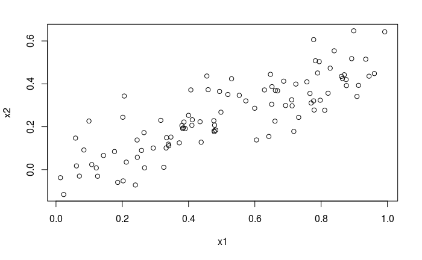

```r
plot(x1,x2)
```

Problem 14c : Fitting a linear model Equation $y=2+2x_1+0.3x_2+\epsilon,x_2=0.5x_1$

```r
lm.fit14c <- lm(y~x1+x2)
summary(lm.fit14c)
```

```
Call:
lm(formula = y ~ x1 + x2)

Residuals:
    Min      1Q  Median      3Q     Max
-2.8311 -0.7273 -0.0537  0.6338  2.3359

Coefficients:
            Estimate Std. Error t value Pr(>|t|)
(Intercept)   2.1305     0.2319   9.188 7.61e-15 ***
x1            1.4396     0.7212   1.996   0.0487 *
x2            1.0097     1.1337   0.891   0.3754
---
Signif. codes:  0 ‘***’ 0.001 ‘**’ 0.01 ‘*’ 0.05 ‘.’ 0.1 ‘ ’ 1

Residual standard error: 1.056 on 97 degrees of freedom
Multiple R-squared:  0.2088,    Adjusted R-squared:  0.1925
F-statistic:  12.8 on 2 and 97 DF,  p-value: 1.164e-05
```

Estimated $\beta_0,\beta_1,\beta_2=2.13,1.5,1$ Actual $\beta_0,\beta_1,\beta_2=2,2,0.3$

x2 has high p value, so the null hypothesis$\beta_2=0$ cannot be rejected

Problem 14d: Fitting only for x1

```r
lm.fit14d <- lm(y~x1)
summary(lm.fit14d)
```

```
Call:
lm(formula = y ~ x1)

Residuals:
     Min       1Q   Median       3Q      Max
-2.89495 -0.66874 -0.07785  0.59221  2.45560

Coefficients:
            Estimate Std. Error t value Pr(>|t|)
(Intercept)   2.1124     0.2307   9.155 8.27e-15 ***
x1            1.9759     0.3963   4.986 2.66e-06 ***
---
Signif. codes:  0 ‘***’ 0.001 ‘**’ 0.01 ‘*’ 0.05 ‘.’ 0.1 ‘ ’ 1

Residual standard error: 1.055 on 98 degrees of freedom
Multiple R-squared:  0.2024,    Adjusted R-squared:  0.1942
F-statistic: 24.86 on 1 and 98 DF,  p-value: 2.661e-06
```

p-value and F static proves that the null hypothesis can be rejected

Problem 14e: Fitting for x2 alone

```r
lm.fit14e <- lm(y~x2)
summary(lm.fit14e)
```

```
Call:
lm(formula = y ~ x2)

Residuals:
     Min       1Q   Median       3Q      Max
-2.62687 -0.75156 -0.03598  0.72383  2.44890

Coefficients:
            Estimate Std. Error t value Pr(>|t|)
(Intercept)   2.3899     0.1949   12.26  < 2e-16 ***
x2            2.8996     0.6330    4.58 1.37e-05 ***
---
Signif. codes:  0 ‘***’ 0.001 ‘**’ 0.01 ‘*’ 0.05 ‘.’ 0.1 ‘ ’ 1

Residual standard error: 1.072 on 98 degrees of freedom
Multiple R-squared:  0.1763,    Adjusted R-squared:  0.1679
F-statistic: 20.98 on 1 and 98 DF,  p-value: 1.366e-05
```

p-value and F static proves that the null hypothesis can be rejected

Problem 14f : The results contradict due to the linearity between x1 and x2. This can be examined by looking at the correlation matrix. It is better to look at the VIF.

```r
library(car)
# For the fit with X1 and X2
vif(lm.fit14c)
```

```
      x1       x2
3.304993 3.304993
```

Not sure about how to interpret these values.

Problem 14g:

```r
x1 <- c(x1,0.1)
x2 <- c(x2,0.8)
y <- c(y,6)
lm.fit14g1 <- lm(y~x1+x2)
lm.fit14g2 <- lm(y~x1)
lm.fit14g3 <- lm(y~x2)
summary(lm.fit14g1)
```

```
Call:
lm(formula = y ~ x1 + x2)

Residuals:
     Min       1Q   Median       3Q      Max
-2.73348 -0.69318 -0.05263  0.66385  2.30619

Coefficients:
            Estimate Std. Error t value Pr(>|t|)
(Intercept)   2.2267     0.2314   9.624 7.91e-16 ***
x1            0.5394     0.5922   0.911  0.36458
x2            2.5146     0.8977   2.801  0.00614 **
---
Signif. codes:  0 ‘***’ 0.001 ‘**’ 0.01 ‘*’ 0.05 ‘.’ 0.1 ‘ ’ 1

Residual standard error: 1.075 on 98 degrees of freedom
Multiple R-squared:  0.2188,    Adjusted R-squared:  0.2029
F-statistic: 13.72 on 2 and 98 DF,  p-value: 5.564e-06
```

```r
summary(lm.fit14g2)
```

```
Call:
lm(formula = y ~ x1)

Residuals:
    Min      1Q  Median      3Q     Max
-2.8897 -0.6556 -0.0909  0.5682  3.5665

Coefficients:
            Estimate Std. Error t value Pr(>|t|)
(Intercept)   2.2569     0.2390   9.445 1.78e-15 ***
x1            1.7657     0.4124   4.282 4.29e-05 ***
---
Signif. codes:  0 ‘***’ 0.001 ‘**’ 0.01 ‘*’ 0.05 ‘.’ 0.1 ‘ ’ 1

Residual standard error: 1.111 on 99 degrees of freedom
Multiple R-squared:  0.1562,    Adjusted R-squared:  0.1477
F-statistic: 18.33 on 1 and 99 DF,  p-value: 4.295e-05
```

```r
summary(lm.fit14g3)
```

```
Call:
lm(formula = y ~ x2)

Residuals:
     Min       1Q   Median       3Q      Max
-2.64729 -0.71021 -0.06899  0.72699  2.38074

Coefficients:
            Estimate Std. Error t value Pr(>|t|)
(Intercept)   2.3451     0.1912  12.264  < 2e-16 ***
x2            3.1190     0.6040   5.164 1.25e-06 ***
---
Signif. codes:  0 ‘***’ 0.001 ‘**’ 0.01 ‘*’ 0.05 ‘.’ 0.1 ‘ ’ 1

Residual standard error: 1.074 on 99 degrees of freedom
Multiple R-squared:  0.2122,    Adjusted R-squared:  0.2042
F-statistic: 26.66 on 1 and 99 DF,  p-value: 1.253e-06
```

It is an outlier. Checking with diagnostic plots

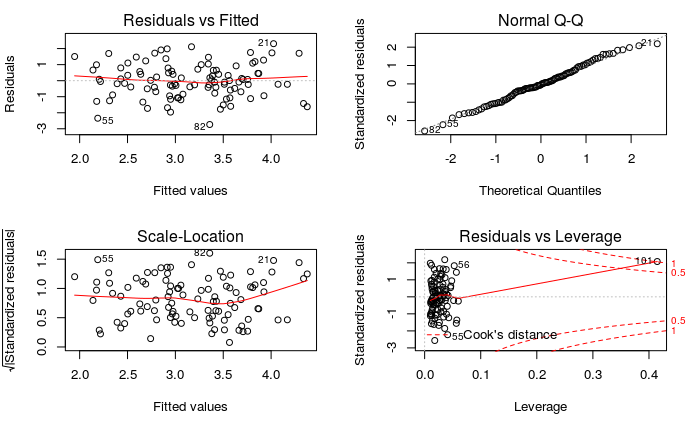

```r
par(mfrow=c(2,2))
plot(lm.fit14g1)
```

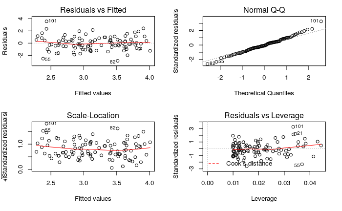

```r
plot(lm.fit14g2)
```

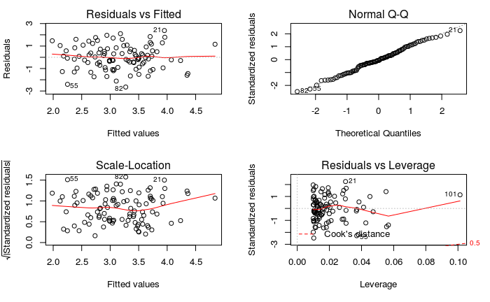

```r
plot(lm.fit14g3)
```

Looks like an outlier, in the second case $y\equiv x1$, since the studentized residual is over 3.

## Problem 15a : Plots and linear regression to each variable

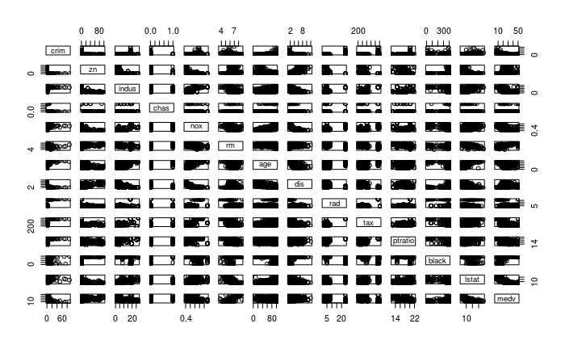

```r
library(MASS)
# Plots
pairs(Boston)
```

```r
DF <- Boston
summary(DF)
```

```
      crim                zn             indus            chas
 Min.   : 0.00632   Min.   :  0.00   Min.   : 0.46   Min.   :0.00000
 1st Qu.: 0.08204   1st Qu.:  0.00   1st Qu.: 5.19   1st Qu.:0.00000
 Median : 0.25651   Median :  0.00   Median : 9.69   Median :0.00000
 Mean   : 3.61352   Mean   : 11.36   Mean   :11.14   Mean   :0.06917
 3rd Qu.: 3.67708   3rd Qu.: 12.50   3rd Qu.:18.10   3rd Qu.:0.00000
 Max.   :88.97620   Max.   :100.00   Max.   :27.74   Max.   :1.00000
      nox               rm             age              dis              rad
 Min.   :0.3850   Min.   :3.561   Min.   :  2.90   Min.   : 1.130   Min.   : 1.000
 1st Qu.:0.4490   1st Qu.:5.886   1st Qu.: 45.02   1st Qu.: 2.100   1st Qu.: 4.000
 Median :0.5380   Median :6.208   Median : 77.50   Median : 3.207   Median : 5.000
 Mean   :0.5547   Mean   :6.285   Mean   : 68.57   Mean   : 3.795   Mean   : 9.549
 3rd Qu.:0.6240   3rd Qu.:6.623   3rd Qu.: 94.08   3rd Qu.: 5.188   3rd Qu.:24.000
 Max.   :0.8710   Max.   :8.780   Max.   :100.00   Max.   :12.127   Max.   :24.000
      tax           ptratio          black            lstat            medv
 Min.   :187.0   Min.   :12.60   Min.   :  0.32   Min.   : 1.73   Min.   : 5.00
 1st Qu.:279.0   1st Qu.:17.40   1st Qu.:375.38   1st Qu.: 6.95   1st Qu.:17.02
 Median :330.0   Median :19.05   Median :391.44   Median :11.36   Median :21.20
 Mean   :408.2   Mean   :18.46   Mean   :356.67   Mean   :12.65   Mean   :22.53
 3rd Qu.:666.0   3rd Qu.:20.20   3rd Qu.:396.23   3rd Qu.:16.95   3rd Qu.:25.00
 Max.   :711.0   Max.   :22.00   Max.   :396.90   Max.   :37.97   Max.   :50.00
```

```r
# Not a good way to do it
attach(Boston)
summary(lm(crim~zn))
```

```
Call:
lm(formula = crim ~ zn)

Residuals:
   Min     1Q Median     3Q    Max
-4.429 -4.222 -2.620  1.250 84.523

Coefficients:
            Estimate Std. Error t value Pr(>|t|)
(Intercept)  4.45369    0.41722  10.675  < 2e-16 ***
zn          -0.07393    0.01609  -4.594 5.51e-06 ***
---
Signif. codes:  0 ‘***’ 0.001 ‘**’ 0.01 ‘*’ 0.05 ‘.’ 0.1 ‘ ’ 1

Residual standard error: 8.435 on 504 degrees of freedom
Multiple R-squared:  0.04019,   Adjusted R-squared:  0.03828
F-statistic:  21.1 on 1 and 504 DF,  p-value: 5.506e-06
```

```r
summary(lm(crim~indus))
```

```
Call:
lm(formula = crim ~ indus)

Residuals:
    Min      1Q  Median      3Q     Max
-11.972  -2.698  -0.736   0.712  81.813

Coefficients:
            Estimate Std. Error t value Pr(>|t|)
(Intercept) -2.06374    0.66723  -3.093  0.00209 **
indus        0.50978    0.05102   9.991  < 2e-16 ***
---
Signif. codes:  0 ‘***’ 0.001 ‘**’ 0.01 ‘*’ 0.05 ‘.’ 0.1 ‘ ’ 1

Residual standard error: 7.866 on 504 degrees of freedom
Multiple R-squared:  0.1653,    Adjusted R-squared:  0.1637
F-statistic: 99.82 on 1 and 504 DF,  p-value: < 2.2e-16
```

```r
summary(lm(crim~chas))
```

```
Call:
lm(formula = crim ~ chas)

Residuals:
   Min     1Q Median     3Q    Max
-3.738 -3.661 -3.435  0.018 85.232

Coefficients:
            Estimate Std. Error t value Pr(>|t|)
(Intercept)   3.7444     0.3961   9.453   <2e-16 ***
chas         -1.8928     1.5061  -1.257    0.209
---
Signif. codes:  0 ‘***’ 0.001 ‘**’ 0.01 ‘*’ 0.05 ‘.’ 0.1 ‘ ’ 1

Residual standard error: 8.597 on 504 degrees of freedom
Multiple R-squared:  0.003124,  Adjusted R-squared:  0.001146
F-statistic: 1.579 on 1 and 504 DF,  p-value: 0.2094
```

```r
summary(lm(crim~nox))
```

```
Call:
lm(formula = crim ~ nox)

Residuals:
    Min      1Q  Median      3Q     Max
-12.371  -2.738  -0.974   0.559  81.728

Coefficients:
            Estimate Std. Error t value Pr(>|t|)
(Intercept)  -13.720      1.699  -8.073 5.08e-15 ***
nox           31.249      2.999  10.419  < 2e-16 ***
---
Signif. codes:  0 ‘***’ 0.001 ‘**’ 0.01 ‘*’ 0.05 ‘.’ 0.1 ‘ ’ 1

Residual standard error: 7.81 on 504 degrees of freedom
Multiple R-squared:  0.1772,    Adjusted R-squared:  0.1756
F-statistic: 108.6 on 1 and 504 DF,  p-value: < 2.2e-16
```

```r
summary(lm(crim~rm))
```

```
Call:
lm(formula = crim ~ rm)

Residuals:
   Min     1Q Median     3Q    Max
-6.604 -3.952 -2.654  0.989 87.197

Coefficients:
            Estimate Std. Error t value Pr(>|t|)
(Intercept)   20.482      3.365   6.088 2.27e-09 ***
rm            -2.684      0.532  -5.045 6.35e-07 ***
---
Signif. codes:  0 ‘***’ 0.001 ‘**’ 0.01 ‘*’ 0.05 ‘.’ 0.1 ‘ ’ 1

Residual standard error: 8.401 on 504 degrees of freedom
Multiple R-squared:  0.04807,   Adjusted R-squared:  0.04618
F-statistic: 25.45 on 1 and 504 DF,  p-value: 6.347e-07
```

```r
summary(lm(crim~age))
```

```
Call:
lm(formula = crim ~ age)

Residuals:
   Min     1Q Median     3Q    Max
-6.789 -4.257 -1.230  1.527 82.849

Coefficients:
            Estimate Std. Error t value Pr(>|t|)
(Intercept) -3.77791    0.94398  -4.002 7.22e-05 ***
age          0.10779    0.01274   8.463 2.85e-16 ***
---
Signif. codes:  0 ‘***’ 0.001 ‘**’ 0.01 ‘*’ 0.05 ‘.’ 0.1 ‘ ’ 1

Residual standard error: 8.057 on 504 degrees of freedom
Multiple R-squared:  0.1244,    Adjusted R-squared:  0.1227
F-statistic: 71.62 on 1 and 504 DF,  p-value: 2.855e-16
```

```r
summary(lm(crim~dis))
```

```
Call:
lm(formula = crim ~ dis)

Residuals:
   Min     1Q Median     3Q    Max
-6.708 -4.134 -1.527  1.516 81.674

Coefficients:
            Estimate Std. Error t value Pr(>|t|)
(Intercept)   9.4993     0.7304  13.006   <2e-16 ***
dis          -1.5509     0.1683  -9.213   <2e-16 ***
---
Signif. codes:  0 ‘***’ 0.001 ‘**’ 0.01 ‘*’ 0.05 ‘.’ 0.1 ‘ ’ 1

Residual standard error: 7.965 on 504 degrees of freedom
Multiple R-squared:  0.1441,    Adjusted R-squared:  0.1425
F-statistic: 84.89 on 1 and 504 DF,  p-value: < 2.2e-16
```

```r
summary(lm(crim~rad))
```

```
Call:
lm(formula = crim ~ rad)

Residuals:
    Min      1Q  Median      3Q     Max
-10.164  -1.381  -0.141   0.660  76.433

Coefficients:
            Estimate Std. Error t value Pr(>|t|)
(Intercept) -2.28716    0.44348  -5.157 3.61e-07 ***
rad          0.61791    0.03433  17.998  < 2e-16 ***
---
Signif. codes:  0 ‘***’ 0.001 ‘**’ 0.01 ‘*’ 0.05 ‘.’ 0.1 ‘ ’ 1

Residual standard error: 6.718 on 504 degrees of freedom
Multiple R-squared:  0.3913,    Adjusted R-squared:   0.39
F-statistic: 323.9 on 1 and 504 DF,  p-value: < 2.2e-16
```

```r
summary(lm(crim~tax))
```

```
Call:
lm(formula = crim ~ tax)

Residuals:
    Min      1Q  Median      3Q     Max
-12.513  -2.738  -0.194   1.065  77.696

Coefficients:
             Estimate Std. Error t value Pr(>|t|)
(Intercept) -8.528369   0.815809  -10.45   <2e-16 ***
tax          0.029742   0.001847   16.10   <2e-16 ***
---
Signif. codes:  0 ‘***’ 0.001 ‘**’ 0.01 ‘*’ 0.05 ‘.’ 0.1 ‘ ’ 1

Residual standard error: 6.997 on 504 degrees of freedom
Multiple R-squared:  0.3396,    Adjusted R-squared:  0.3383
F-statistic: 259.2 on 1 and 504 DF,  p-value: < 2.2e-16
```

```r
summary(lm(crim~ptratio))
```

```
Call:
lm(formula = crim ~ ptratio)

Residuals:
   Min     1Q Median     3Q    Max
-7.654 -3.985 -1.912  1.825 83.353

Coefficients:
            Estimate Std. Error t value Pr(>|t|)
(Intercept) -17.6469     3.1473  -5.607 3.40e-08 ***
ptratio       1.1520     0.1694   6.801 2.94e-11 ***
---
Signif. codes:  0 ‘***’ 0.001 ‘**’ 0.01 ‘*’ 0.05 ‘.’ 0.1 ‘ ’ 1

Residual standard error: 8.24 on 504 degrees of freedom
Multiple R-squared:  0.08407,   Adjusted R-squared:  0.08225
F-statistic: 46.26 on 1 and 504 DF,  p-value: 2.943e-11
```

```r
summary(lm(crim~black))
```

```
Call:
lm(formula = crim ~ black)

Residuals:
    Min      1Q  Median      3Q     Max
-13.756  -2.299  -2.095  -1.296  86.822

Coefficients:
             Estimate Std. Error t value Pr(>|t|)
(Intercept) 16.553529   1.425903  11.609   <2e-16 ***
black       -0.036280   0.003873  -9.367   <2e-16 ***
---
Signif. codes:  0 ‘***’ 0.001 ‘**’ 0.01 ‘*’ 0.05 ‘.’ 0.1 ‘ ’ 1

Residual standard error: 7.946 on 504 degrees of freedom
Multiple R-squared:  0.1483,    Adjusted R-squared:  0.1466
F-statistic: 87.74 on 1 and 504 DF,  p-value: < 2.2e-16
```

```r
summary(lm(crim~lstat))
```

```
Call:
lm(formula = crim ~ lstat)

Residuals:
    Min      1Q  Median      3Q     Max
-13.925  -2.822  -0.664   1.079  82.862

Coefficients:
            Estimate Std. Error t value Pr(>|t|)
(Intercept) -3.33054    0.69376  -4.801 2.09e-06 ***
lstat        0.54880    0.04776  11.491  < 2e-16 ***
---
Signif. codes:  0 ‘***’ 0.001 ‘**’ 0.01 ‘*’ 0.05 ‘.’ 0.1 ‘ ’ 1

Residual standard error: 7.664 on 504 degrees of freedom
Multiple R-squared:  0.2076,    Adjusted R-squared:  0.206
F-statistic:   132 on 1 and 504 DF,  p-value: < 2.2e-16
```

```r
summary(lm(crim~medv))
```

```
Call:
lm(formula = crim ~ medv)

Residuals:
   Min     1Q Median     3Q    Max
-9.071 -4.022 -2.343  1.298 80.957

Coefficients:
            Estimate Std. Error t value Pr(>|t|)
(Intercept) 11.79654    0.93419   12.63   <2e-16 ***
medv        -0.36316    0.03839   -9.46   <2e-16 ***
---
Signif. codes:  0 ‘***’ 0.001 ‘**’ 0.01 ‘*’ 0.05 ‘.’ 0.1 ‘ ’ 1

Residual standard error: 7.934 on 504 degrees of freedom
Multiple R-squared:  0.1508,    Adjusted R-squared:  0.1491
F-statistic: 89.49 on 1 and 504 DF,  p-value: < 2.2e-16
```

Observations For chas, the p value is high.

## Problem 15b: Fitting a multiple linear regression

```r
library(MASS)
lm.fit15b <- lm(crim~.,data = Boston)
summary(lm.fit15b)
```

```
Call:
lm(formula = crim ~ ., data = Boston)

Residuals:
   Min     1Q Median     3Q    Max
-9.924 -2.120 -0.353  1.019 75.051

Coefficients:
              Estimate Std. Error t value Pr(>|t|)
(Intercept)  17.033228   7.234903   2.354 0.018949 *
zn            0.044855   0.018734   2.394 0.017025 *
indus        -0.063855   0.083407  -0.766 0.444294
chas         -0.749134   1.180147  -0.635 0.525867
nox         -10.313535   5.275536  -1.955 0.051152 .
rm            0.430131   0.612830   0.702 0.483089
age           0.001452   0.017925   0.081 0.935488
dis          -0.987176   0.281817  -3.503 0.000502 ***
rad           0.588209   0.088049   6.680 6.46e-11 ***
tax          -0.003780   0.005156  -0.733 0.463793
ptratio      -0.271081   0.186450  -1.454 0.146611
black        -0.007538   0.003673  -2.052 0.040702 *
lstat         0.126211   0.075725   1.667 0.096208 .
medv         -0.198887   0.060516  -3.287 0.001087 **
---
Signif. codes:  0 ‘***’ 0.001 ‘**’ 0.01 ‘*’ 0.05 ‘.’ 0.1 ‘ ’ 1

Residual standard error: 6.439 on 492 degrees of freedom
Multiple R-squared:  0.454, Adjusted R-squared:  0.4396
F-statistic: 31.47 on 13 and 492 DF,  p-value: < 2.2e-16
```

Checking linear model fit

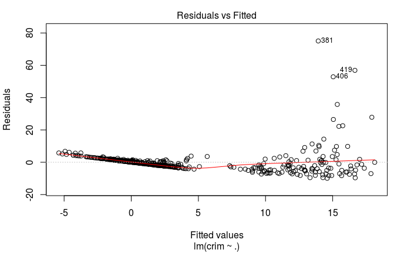

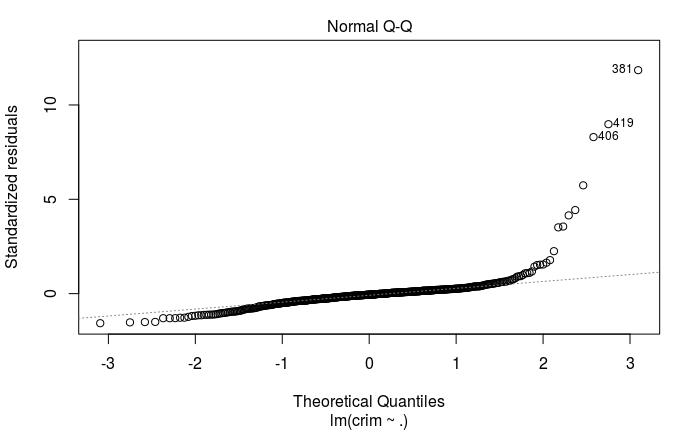

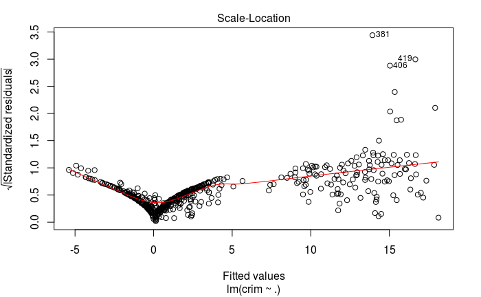

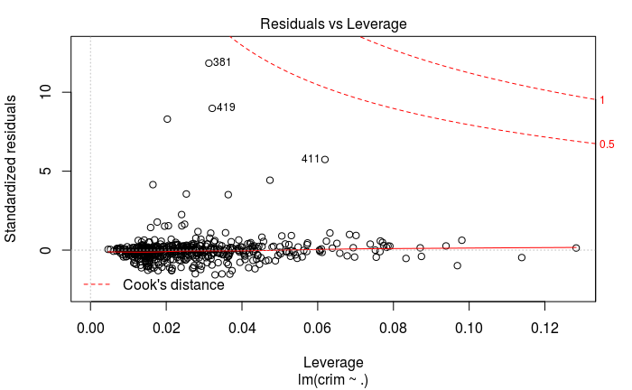

```r
plot(lm.fit15b)
```

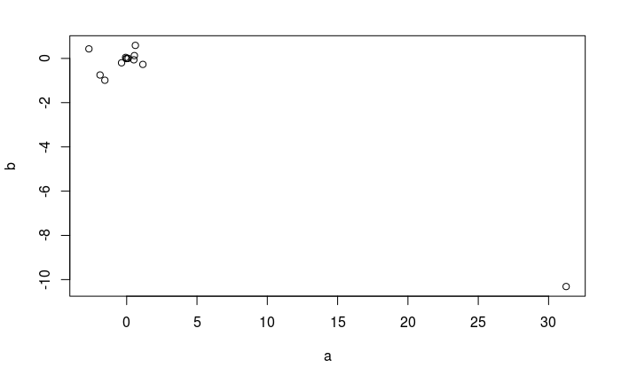

```r
attach(Boston)
a <- c(coefficients(lm(crim~zn))[2],
coefficients(lm(crim~indus))[2],
coefficients(lm(crim~chas))[2],
coefficients(lm(crim~nox))[2],
coefficients(lm(crim~rm))[2],
coefficients(lm(crim~age))[2],
coefficients(lm(crim~dis))[2],
coefficients(lm(crim~rad))[2],
coefficients(lm(crim~tax))[2],
coefficients(lm(crim~ptratio))[2],
coefficients(lm(crim~black))[2],
coefficients(lm(crim~lstat))[2],
coefficients(lm(crim~medv))[2])
b <- coefficients(lm.fit15b)[2:14]
plot(b~a)
```

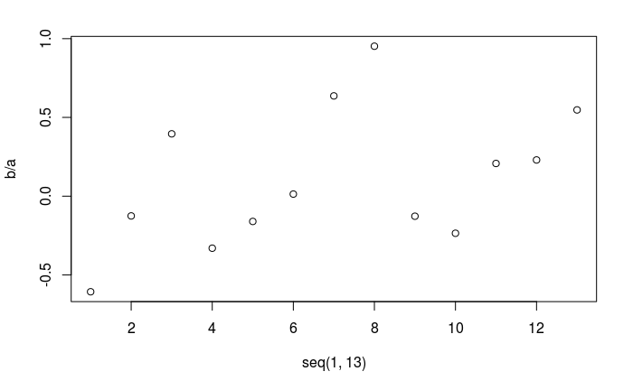

```r
plot(seq(1,13),b/a)
```

Checking the VIF

```r
library(car)
vif(lm.fit15b)
```

```
      zn    indus     chas      nox       rm      age      dis      rad      tax
2.325094 3.987753 1.094326 4.551563 2.258113 3.100801 4.289041 7.158834 9.195495
 ptratio    black    lstat     medv
1.984489 1.369741 3.561476 3.772856
```

Fitting a non linear model to the third power.

```r
attach(Boston)
lm.fit15d <- lm(crim~dis+I(dis^2)+I(dis^3)+rad+I(rad^2)+I(rad^3)+black+I(black^2)+I(black^3)+zn+I(zn^2)+I(zn^3)+medv+I(medv^2)+I(medv^3))
summary(lm.fit15d)
```

```
Call:
lm(formula = crim ~ dis + I(dis^2) + I(dis^3) + rad + I(rad^2) +
    I(rad^3) + black + I(black^2) + I(black^3) + zn + I(zn^2) +
    I(zn^3) + medv + I(medv^2) + I(medv^3))

Residuals:
    Min      1Q  Median      3Q     Max
-14.846  -1.610  -0.062   1.126  70.953

Coefficients:
              Estimate Std. Error t value Pr(>|t|)
(Intercept)  4.507e+01  4.364e+00  10.327  < 2e-16 ***
dis         -5.852e+00  1.621e+00  -3.611 0.000337 ***
I(dis^2)     1.041e+00  3.137e-01   3.318 0.000973 ***
I(dis^3)    -5.379e-02  1.792e-02  -3.001 0.002827 **
rad          4.388e-01  9.537e-01   0.460 0.645645
I(rad^2)    -4.780e-02  1.359e-01  -0.352 0.725086
I(rad^3)     1.831e-03  4.184e-03   0.438 0.661801
black       -2.964e-02  4.185e-02  -0.708 0.479179
I(black^2)   4.181e-05  2.214e-04   0.189 0.850282
I(black^3)   4.201e-08  3.243e-07   0.130 0.897005
zn          -5.036e-02  8.785e-02  -0.573 0.566727
I(zn^2)      1.254e-03  2.866e-03   0.438 0.661828
I(zn^3)     -8.868e-06  2.292e-05  -0.387 0.698971
medv        -3.711e+00  4.186e-01  -8.865  < 2e-16 ***
I(medv^2)    1.260e-01  1.620e-02   7.778 4.39e-14 ***
I(medv^3)   -1.321e-03  1.905e-04  -6.938 1.26e-11 ***
---
Signif. codes:  0 ‘***’ 0.001 ‘**’ 0.01 ‘*’ 0.05 ‘.’ 0.1 ‘ ’ 1

Residual standard error: 5.853 on 490 degrees of freedom
Multiple R-squared:  0.5508,    Adjusted R-squared:  0.537
F-statistic: 40.05 on 15 and 490 DF,  p-value: < 2.2e-16
```

rad is ‘interesting’